# Supervised Learning - Foundations Project: ReCell

## Problem Statement

### Business Context

Buying and selling used phones and tablets used to be something that happened on a handful of online marketplace sites. But the used and refurbished device market has grown considerably over the past decade, and a new IDC (International Data Corporation) forecast predicts that the used phone market would be worth \$52.7bn by 2023 with a compound annual growth rate (CAGR) of 13.6% from 2018 to 2023. This growth can be attributed to an uptick in demand for used phones and tablets that offer considerable savings compared with new models.

Refurbished and used devices continue to provide cost-effective alternatives to both consumers and businesses that are looking to save money when purchasing one. There are plenty of other benefits associated with the used device market. Used and refurbished devices can be sold with warranties and can also be insured with proof of purchase. Third-party vendors/platforms, such as Verizon, Amazon, etc., provide attractive offers to customers for refurbished devices. Maximizing the longevity of devices through second-hand trade also reduces their environmental impact and helps in recycling and reducing waste. The impact of the COVID-19 outbreak may further boost this segment as consumers cut back on discretionary spending and buy phones and tablets only for immediate needs.

### Objective

The rising potential of this comparatively under-the-radar market fuels the need for an ML-based solution to develop a dynamic pricing strategy for used and refurbished devices. ReCell, a startup aiming to tap the potential in this market, has hired you as a data scientist. They want you to analyze the data provided and build a linear regression model to predict the price of a used phone/tablet and identify factors that significantly influence it.

### Data Description

The data contains the different attributes of used/refurbished phones and tablets. The data was collected in the year 2021. The detailed data dictionary is given below.

- brand_name: Name of manufacturing brand
- os: OS on which the device runs
- screen_size: Size of the screen in cm
- 4g: Whether 4G is available or not
- 5g: Whether 5G is available or not
- main_camera_mp: Resolution of the rear camera in megapixels
- selfie_camera_mp: Resolution of the front camera in megapixels
- int_memory: Amount of internal memory (ROM) in GB
- ram: Amount of RAM in GB
- battery: Energy capacity of the device battery in mAh
- weight: Weight of the device in grams
- release_year: Year when the device model was released
- days_used: Number of days the used/refurbished device has been used
- normalized_new_price: Normalized price of a new device of the same model in euros
- normalized_used_price: Normalized price of the used/refurbished device in euros

## Importing necessary libraries

```python
    # Libraries to help with reading and manipulating data
import numpy as np
import pandas as pd

# Libraries to help with data visualization
import matplotlib.pyplot as plt
import seaborn as sns

sns.set()

# split the data into train and test
from sklearn.model_selection import train_test_split

# to build linear regression_model
from sklearn.linear_model import LinearRegression

# to check model performance
from sklearn.metrics import mean_absolute_error, mean_squared_error, r2_score

# to build linear regression_model using statsmodels
import statsmodels.api as sm

# to compute VIF
from statsmodels.stats.outliers_influence import variance_inflation_factor
```

## Loading the dataset

```python
# loading data
data = pd.read_csv('used_device_data.csv') ## Complete the code to read the data
```

## Data Overview

- Observations
- Sanity checks

```python
data.sample(5) #random sample of rows to access data
```

|  | brand_name | os | screen_size | 4g | 5g | main_camera_mp | selfie_camera_mp | int_memory | ram | battery | weight | release_year | days_used | normalized_used_price | normalized_new_price |
| --- | --- | --- | --- | --- | --- | --- | --- | --- | --- | --- | --- | --- | --- | --- | --- |
| 1043 | Gionee | Android | 10.21 | yes | no | 16.0 | 5.0 | 64.0 | 4.00 | 2530.0 | 207.7 | 2016 | 873 | 5.073360 | 6.307479 |
| 2709 | Sony | Android | 12.83 | yes | no | 13.0 | 5.0 | 16.0 | 4.00 | 2600.0 | 147.0 | 2015 | 842 | 4.307303 | 5.521141 |
| 1330 | Huawei | Android | 25.40 | yes | no | 8.0 | 2.0 | 16.0 | 4.00 | 6660.0 | 495.0 | 2016 | 1049 | 4.870070 | 5.483344 |
| 516 | Alcatel | Others | 7.75 | no | no | 2.0 | 0.3 | 512.0 | 0.25 | 2820.0 | 98.0 | 2015 | 786 | 2.863343 | 3.678324 |
| 3348 | Huawei | Android | 20.32 | yes | yes | 10.5 | 16.0 | 512.0 | 8.00 | 4500.0 | 300.0 | 2020 | 129 | 5.959251 | 7.847841 |

```python
data.shape #3454 total rows , 15 cols
```

```
(3454, 15)
```

```python
data.describe().transpose() #stat summary transposed
```

|  | count | mean | std | min | 25% | 50% | 75% | max |
| --- | --- | --- | --- | --- | --- | --- | --- | --- |
| screen_size | 3454.0 | 13.713115 | 3.805280 | 5.080000 | 12.700000 | 12.830000 | 15.340000 | 30.710000 |
| main_camera_mp | 3275.0 | 9.460208 | 4.815461 | 0.080000 | 5.000000 | 8.000000 | 13.000000 | 48.000000 |
| selfie_camera_mp | 3452.0 | 6.554229 | 6.970372 | 0.000000 | 2.000000 | 5.000000 | 8.000000 | 32.000000 |
| int_memory | 3450.0 | 54.573099 | 84.972371 | 0.010000 | 16.000000 | 32.000000 | 64.000000 | 1024.000000 |
| ram | 3450.0 | 4.036122 | 1.365105 | 0.020000 | 4.000000 | 4.000000 | 4.000000 | 12.000000 |
| battery | 3448.0 | 3133.402697 | 1299.682844 | 500.000000 | 2100.000000 | 3000.000000 | 4000.000000 | 9720.000000 |
| weight | 3447.0 | 182.751871 | 88.413228 | 69.000000 | 142.000000 | 160.000000 | 185.000000 | 855.000000 |
| release_year | 3454.0 | 2015.965258 | 2.298455 | 2013.000000 | 2014.000000 | 2015.500000 | 2018.000000 | 2020.000000 |
| days_used | 3454.0 | 674.869716 | 248.580166 | 91.000000 | 533.500000 | 690.500000 | 868.750000 | 1094.000000 |
| normalized_used_price | 3454.0 | 4.364712 | 0.588914 | 1.536867 | 4.033931 | 4.405133 | 4.755700 | 6.619433 |
| normalized_new_price | 3454.0 | 5.233107 | 0.683637 | 2.901422 | 4.790342 | 5.245892 | 5.673718 | 7.847841 |

```python
data.isnull().sum() # 6 cols have at least 1 missing value, main camera mpx has the most by far at 179
```

```
brand_name                 0
os                         0
screen_size                0
4g                         0
5g                         0
main_camera_mp           179
selfie_camera_mp           2
int_memory                 4
ram                        4
battery                    6
weight                     7
release_year               0
days_used                  0
normalized_used_price      0
normalized_new_price       0
dtype: int64
```

```python
data.duplicated().sum() #no duplicated rows
```

```
0
```

```python
df = data.copy() #copy to keep original intact
```

## Exploratory Data Analysis (EDA)

- EDA is an important part of any project involving data.
- It is important to investigate and understand the data better before building a model with it.
- A few questions have been mentioned below which will help you approach the analysis in the right manner and generate insights from the data.
- A thorough analysis of the data, in addition to the questions mentioned below, should be done.

**Questions**:

1. What does the distribution of normalized used device prices look like?
2. What percentage of the used device market is dominated by Android devices?
3. The amount of RAM is important for the smooth functioning of a device. How does the amount of RAM vary with the brand?
4. A large battery often increases a device's weight, making it feel uncomfortable in the hands. How does the weight vary for phones and tablets offering large batteries (more than 4500 mAh)?
5. Bigger screens are desirable for entertainment purposes as they offer a better viewing experience. How many phones and tablets are available across different brands with a screen size larger than 6 inches?
6. A lot of devices nowadays offer great selfie cameras, allowing us to capture our favorite moments with loved ones. What is the distribution of devices offering greater than 8MP selfie cameras across brands?
7. Which attributes are highly correlated with the normalized price of a used device?

Direct responses to questions are listed below in Red. General headers or commentary remain black

```python
#1 normalized used device prices
def eda_plot(col, df=df):
    plt.figure(figsize=(15, 8))
    sns.boxplot(data=df, x=col)
    plt.show()
    plt.figure(figsize=(15, 8))
    sns.histplot(data=df, x=col);
```

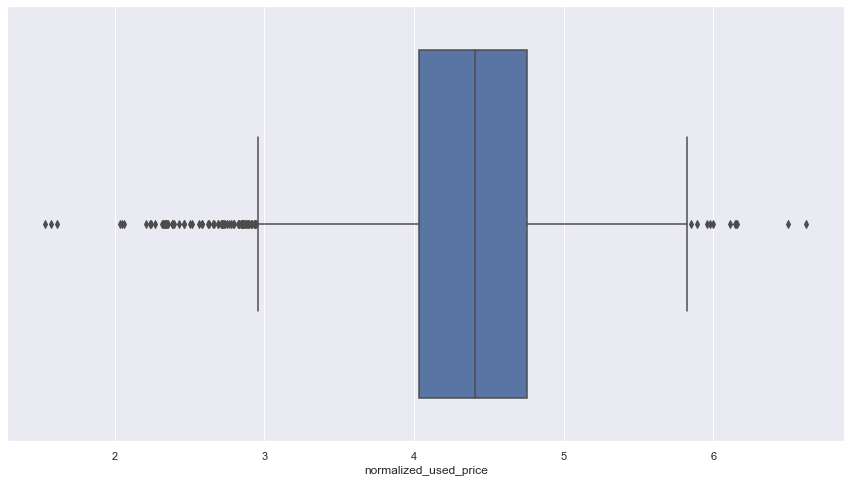

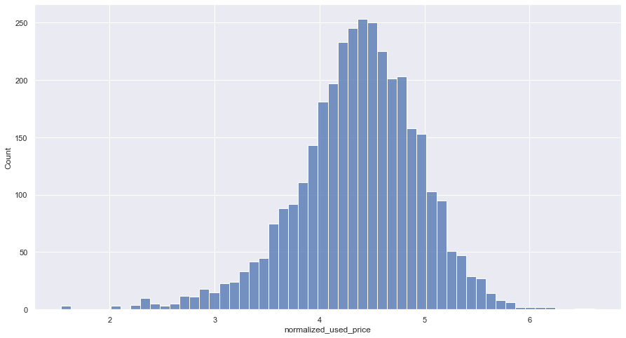

```python
eda_plot('normalized_used_price')
```

1: Judging from the above plots, we can conclude that the normalized used prices of devices are almost normally distributed

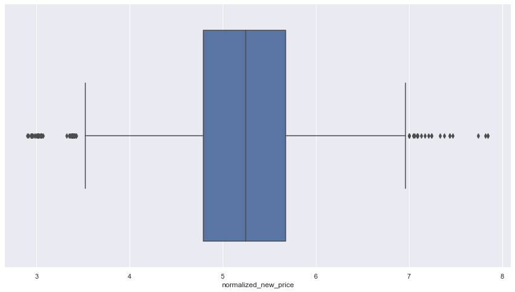

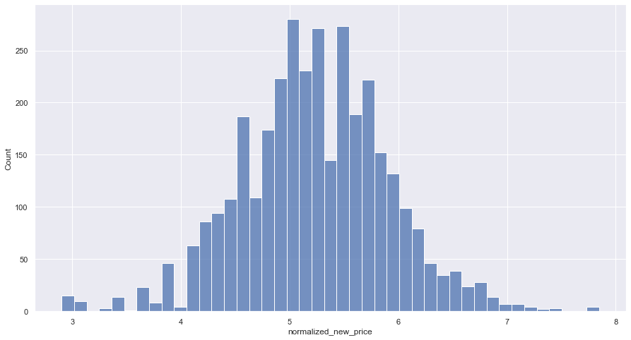

```python
eda_plot('normalized_new_price')
```

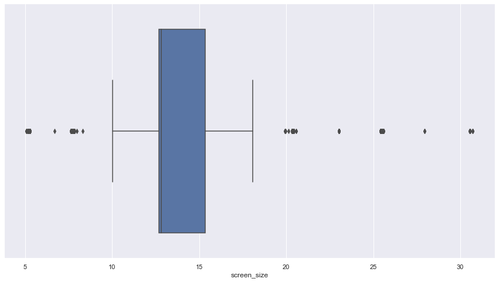

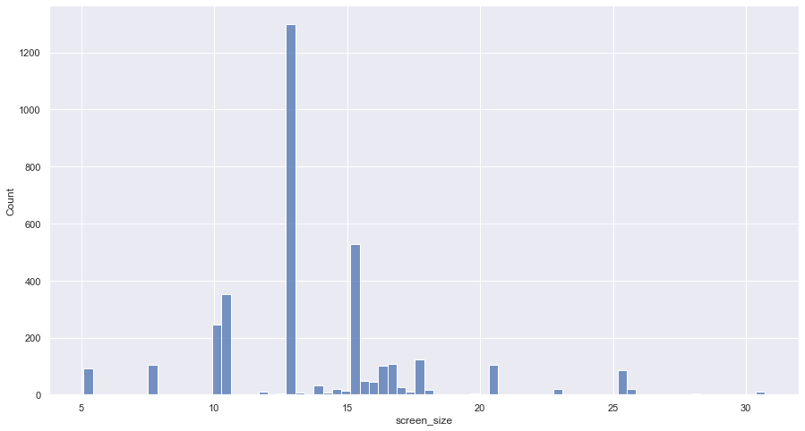

```python
eda_plot('screen_size')
```

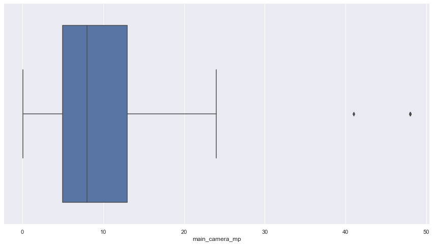

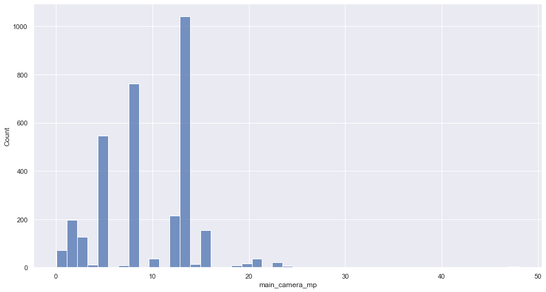

```python
eda_plot('main_camera_mp')
```

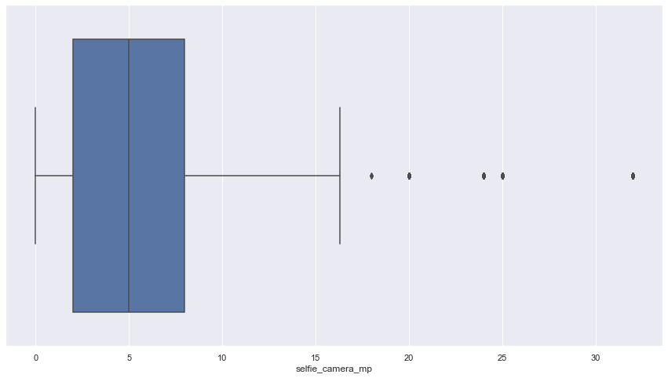

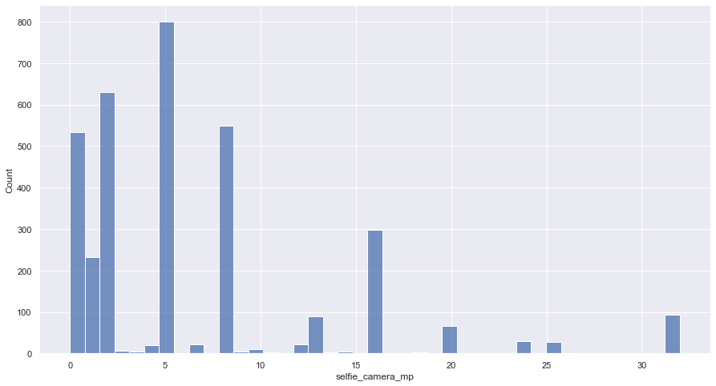

```python
eda_plot('selfie_camera_mp')
```

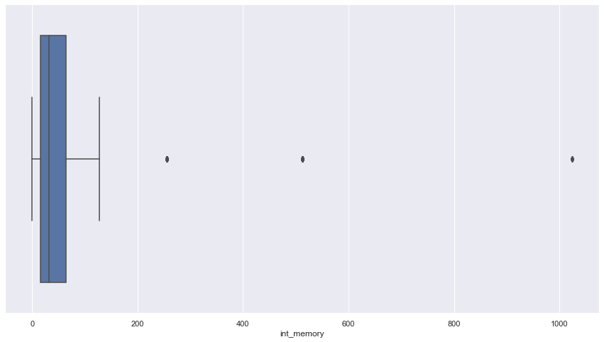

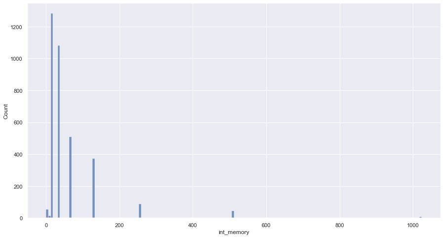

```python
eda_plot('int_memory')
```

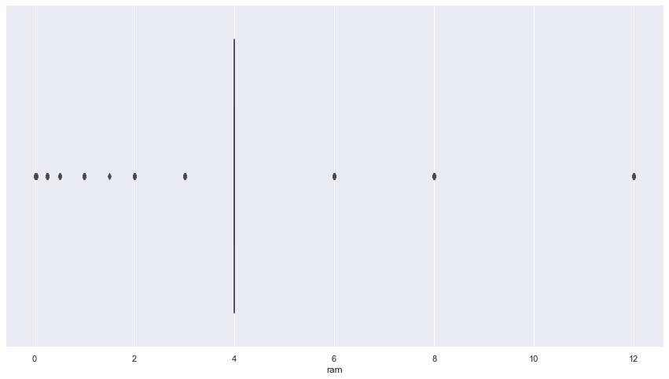

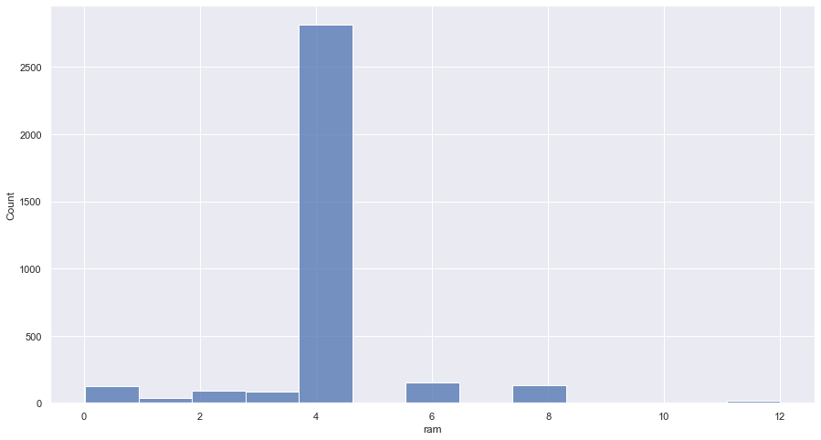

```python
eda_plot('ram')
```

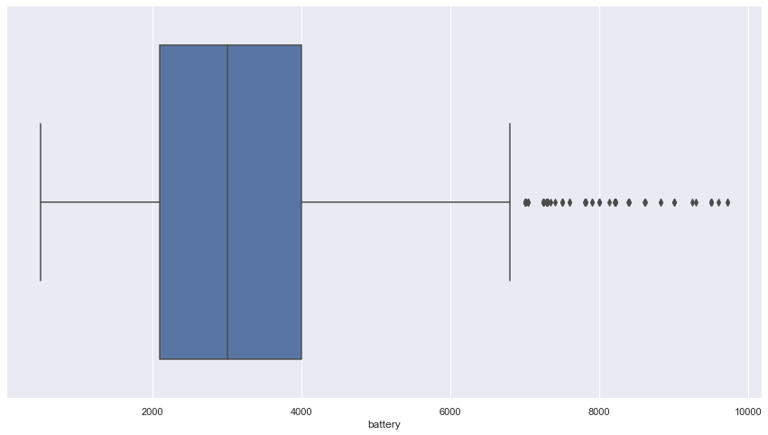

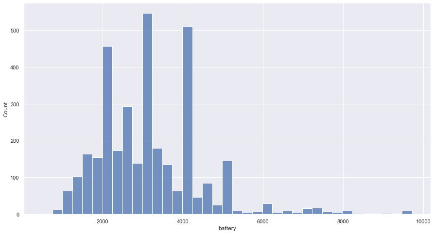

```python
eda_plot('battery')
```

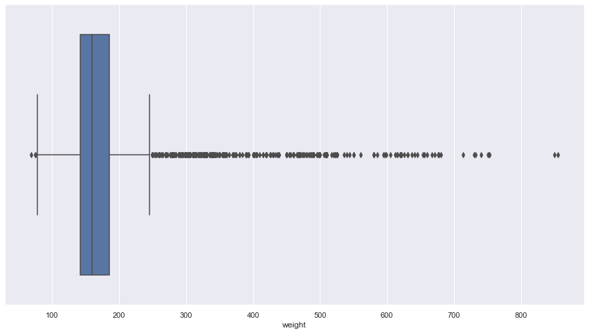

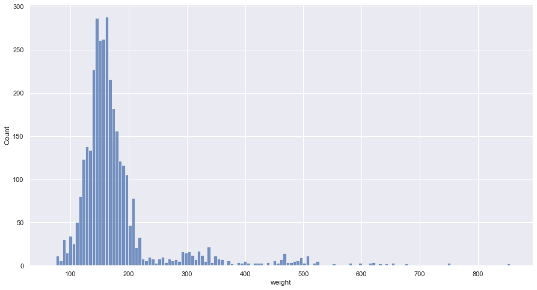

```python
eda_plot('weight')
```

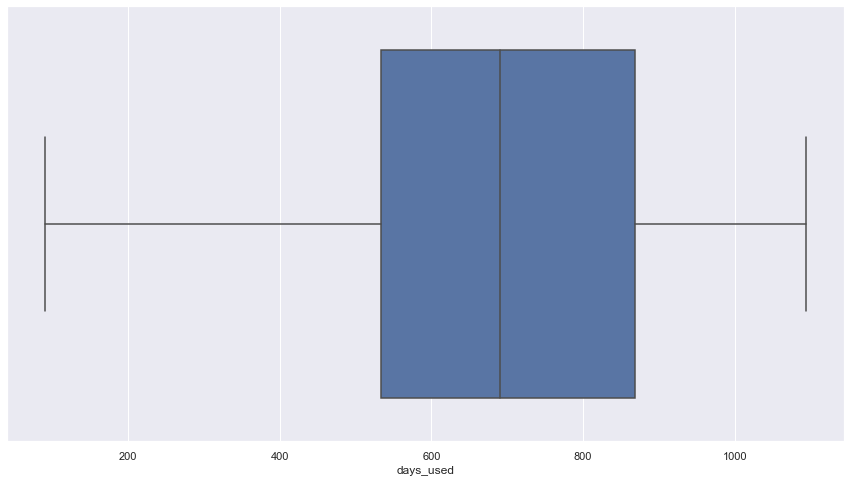

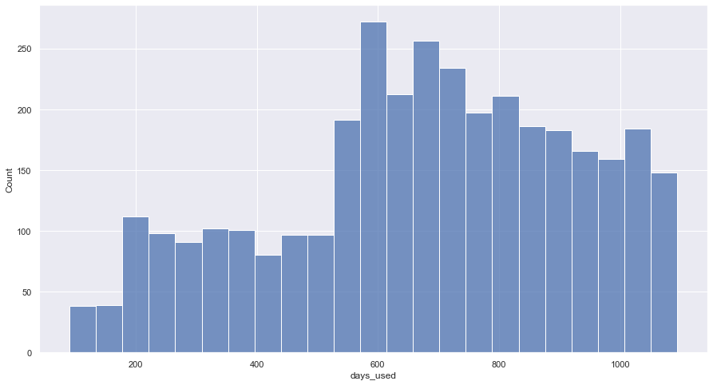

```python
eda_plot('days_used')
```

```python
largest_brands_df = df.value_counts('brand_name', normalize=True).nlargest(10).index #Get top 10 companies by frequency of phones in the dataset
```

```python
subset = df[df['brand_name'].isin(largest_brands_df)] # Create dataframe using indexes from value count above
```

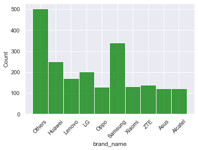

```python
sns.histplot(data=subset, x='brand_name', color='green'); #create green histplot
plt.xticks(rotation=45); #rotate x axis to view data
```

```python
largest_brands_df2 = df.value_counts('brand_name', normalize=True).nlargest(10).mul(100).round(1).astype(str) + '%' #format previous value count as percentage
largest_brands_df2
```

```
brand_name
Others     14.5%
Samsung     9.9%
Huawei      7.3%
LG          5.8%
Lenovo      5.0%
ZTE         4.1%
Xiaomi      3.8%
Oppo        3.7%
Asus        3.5%
Alcatel     3.5%
dtype: object
```

Roughly 10% of the used device market belongs to Samsung. The next closest is Huawei with 7.3%

```python
largest_os_df = df.value_counts('os', normalize=True).nlargest(10).index #Get top 10 companies by frequency of phones in the dataset
```

```python
subset = df[df['os'].isin(largest_os_df)] # Create dataframe using indexes from value count above
```

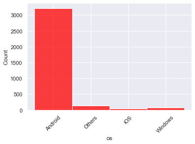

```python
sns.histplot(data=subset, x='os', color='red'); #create green histplot
plt.xticks(rotation=45); #rotate x axis to view data
```

```python
largest_os_df2 = df.value_counts('os', normalize=True).nlargest(10).mul(100).round(1).astype(str) + '%' #format previous value count as percentage
largest_os_df2
```

```
os
Android    93.1%
Others      4.0%
Windows     1.9%
iOS         1.0%
dtype: object
```

2: The Android OS dominates the used market, scoring over 93% of the market share. There is no close competition.

Bi-Variate Checks

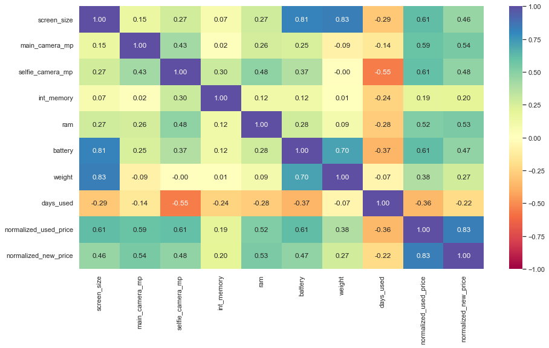

```python
cols = df.select_dtypes(include=np.number).columns.to_list()
cols.remove('release_year')

plt.figure(figsize=(15,8))
sns.heatmap(df[cols].corr(), annot=True, vmin=-1, vmax=1, fmt=".2f", cmap="Spectral");
```

Learnings:

7: Normalized used price is negatively correlated with days used. This indicates a phones value decreases the longer it was in use. On the other hand, used price is correlated positively with new price, indicating that phones that were expensive new, hold thier value when they are used. Finally, regualar factors like screensize, camera and battery have a correlation with the price of a used phone.

- Battery and weight are highly correlated with screen size. This makes sense given that a phone must generally add weight to accomodate these bigger/better features.
- Days used is negatively correlated with every other feature, however it is most negatively correlated with the selfie camera mp. This indicates that newer phones have nicer front cameras in particular which makes sense given recent trends.

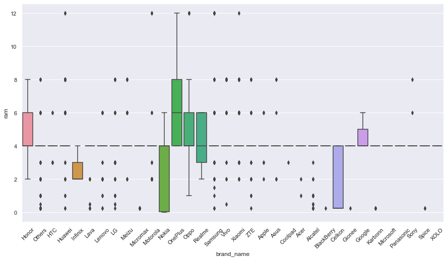

```python
plt.figure(figsize=(15,8))
sns.boxplot(data=df, x='brand_name', y='ram')
plt.xticks(rotation=45);
```

3: Over half of the One Plus branded phones offer more than 4gb of Ram. They are the only company that can make that claim. This indicates their used phones may be a better value as the extra RAM should lead to smoother functioning phones.

4gb of RAM is the standard for most other notable brands

```python
large_battery = df[df['battery'] > 4500] #isolate phones with large battery
large_battery.count()['weight'] #count of values in the weight column for new dataframe
```

```
341
```

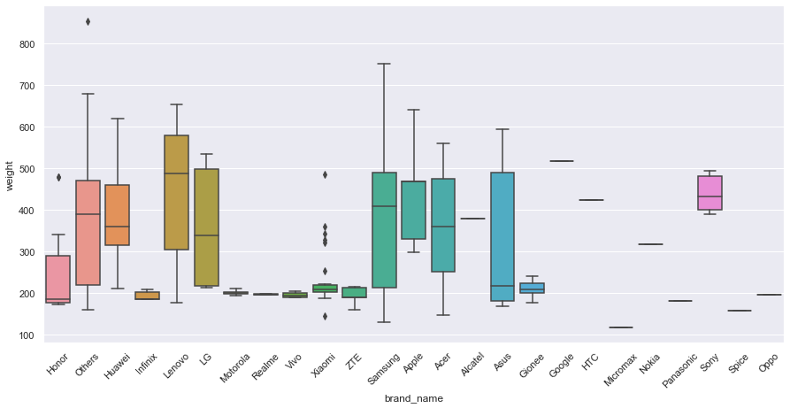

```python
plt.figure(figsize=(15,7))
sns.boxplot(data=large_battery, x='brand_name', y='weight')
plt.xticks(rotation=45);
```

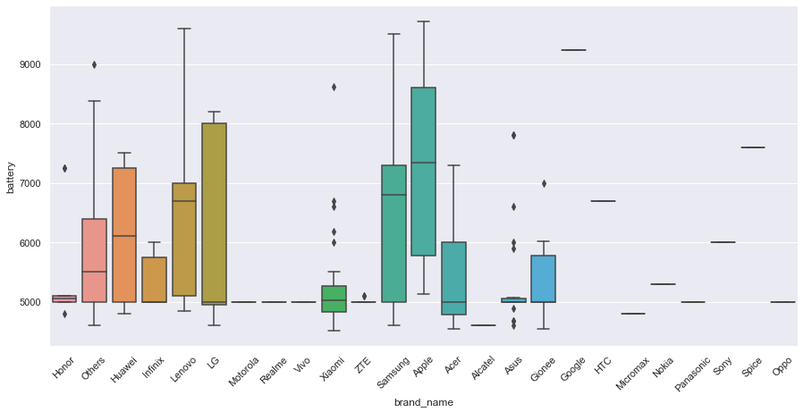

```python
plt.figure(figsize=(15,7))
sns.boxplot(data=large_battery, x='brand_name', y='battery')
plt.xticks(rotation=45);
```

4: overall it appears that battery size varies more across brands than weight. Samsung, Apple, LG, and Lenovo offer the most variety between weight and battery. This suggests that these brands have the most diverse assortment and would be the most likely brand to offer a phone with the features everyone is looking for.

```python
large_screen = df[df['screen_size'] > 6 * 2.54]
large_screen.shape
```

```
(1099, 15)
```

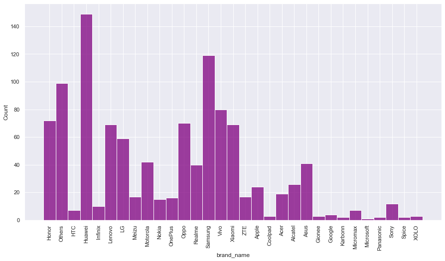

```python
plt.figure(figsize=(15,8))
sns.histplot(data=large_screen, x='brand_name', color='purple'); #create purple histplot
plt.xticks(rotation=90); #rotate x axis 90 to view data
```

5: There are 1099 phones with a "large screen" for those that want easier viewability for thier entertainment. Hauwei offers the most phones, followed by Samsung.

```python
selfie = df[df.selfie_camera_mp > 8]
selfie.shape
```

```
(655, 15)
```

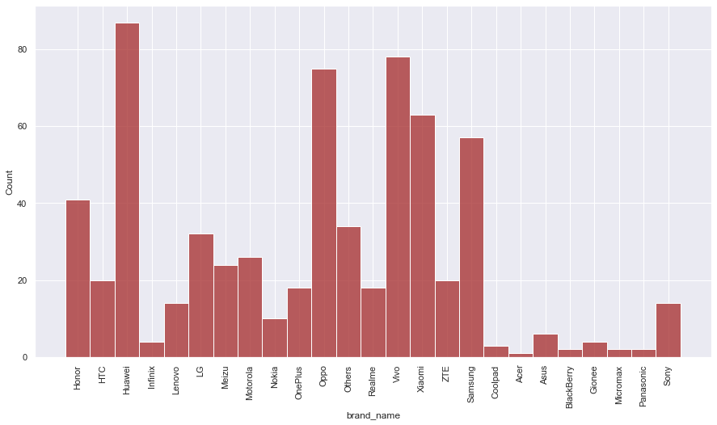

```python
plt.figure(figsize=(15,8))
sns.histplot(data=selfie, x='brand_name', color='brown'); #create brown histplot
plt.xticks(rotation=90); #rotate x axis 90 to view data
```

6: Huawei edges out Vivo and Oppo as the brand with the most phones offering more than 8 mpx on the front facing camera.

```python
main = df[df.main_camera_mp > 16]
main.shape
```

```
(94, 15)
```

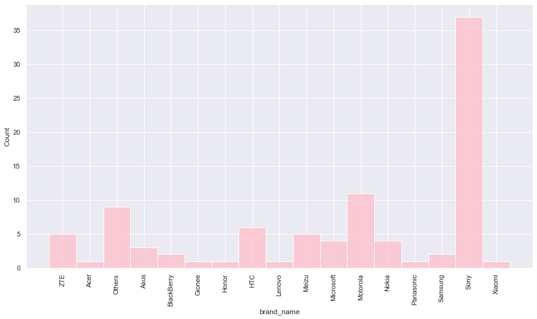

```python
plt.figure(figsize=(15,8))
sns.histplot(data=main, x='brand_name', color='pink'); #create brown histplot
plt.xticks(rotation=90); #rotate x axis 90 to view data
```

Sony dominates the competiton when it comes to the mpx for main cameras. Sony offers 37 options, while the next closest option offers only 11.

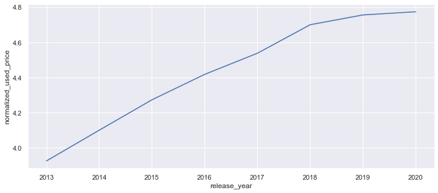

```python
plt.figure(figsize=(12, 5))
sns.lineplot(data=df, x='release_year', y='normalized_used_price', ci=False);
```

Used phones are increasing in price over time (unclear if this is handled for inflation)

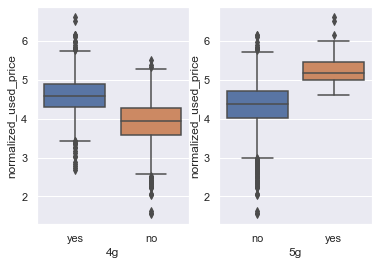

```python
plt.subplot(121)
sns.boxplot(data=df, x="4g", y="normalized_used_price");

plt.subplot(122)
sns.boxplot(data=df, x="5g", y="normalized_used_price");
```

4g and 5g enabled phones can get a higher priced used than those without either network capability.

## Data Preprocessing

- Missing value treatment

```python
df1 = df.copy() #save copy of original
```

```python
df.isnull().sum() # we need to impute (or drop) values for those that are missing.
```

```
brand_name                 0
os                         0
screen_size                0
4g                         0
5g                         0
main_camera_mp           179
selfie_camera_mp           2
int_memory                 4
ram                        4
battery                    6
weight                     7
release_year               0
days_used                  0
normalized_used_price      0
normalized_new_price       0
dtype: int64
```

```python
cols = ["main_camera_mp", "selfie_camera_mp", "battery", "weight"] #isolate columns to groupby brand and release year
```

```python
for col in cols:
    df[col] = df1.groupby(['release_year', 'brand_name'])[col].transform(
        lambda x: x.fillna(x.median())
    ) #use transform function to fill na values with media by grouped columns
```

```python
df1.isnull().sum() #check on missing values
```

```
brand_name                 0
os                         0
screen_size                0
4g                         0
5g                         0
main_camera_mp           179
selfie_camera_mp           2
int_memory                 4
ram                        4
battery                    6
weight                     7
release_year               0
days_used                  0
normalized_used_price      0
normalized_new_price       0
dtype: int64
```

```python
cols = ['main_camera_mp', 'selfie_camera_mp', 'battery', 'weight', 'ram', 'int_memory'] #all other columns, non time dependant
```

```python
for col in cols:
    df1[col] = df1.groupby(['brand_name'])[col].transform(
    lambda x: x.fillna(x.median())
    ) #use transform function to fill na values with media by grouped columns
```

```python
df1.isnull().sum() #check for blank values
```

```
brand_name                0
os                        0
screen_size               0
4g                        0
5g                        0
main_camera_mp           10
selfie_camera_mp          0
int_memory                0
ram                       0
battery                   0
weight                    0
release_year              0
days_used                 0
normalized_used_price     0
normalized_new_price      0
dtype: int64
```

```python
df1['main_camera_mp'] = df1['main_camera_mp'].fillna(df1['main_camera_mp'].median()) #single column fill with median

df1.isnull().sum() #ensure no more nulls
```

```
brand_name               0
os                       0
screen_size              0
4g                       0
5g                       0
main_camera_mp           0
selfie_camera_mp         0
int_memory               0
ram                      0
battery                  0
weight                   0
release_year             0
days_used                0
normalized_used_price    0
normalized_new_price     0
dtype: int64
```

- Feature engineering (if needed)

tracking the years since release will be a much better column for this continues data set instead of tracking the actual year, which is more categorical.

```python
df1['years_since_release'] = 2021 - df1['release_year'] #calculate new column from current year of data collection
df1.drop("release_year", axis=1, inplace=True) #drop original column
df1['years_since_release'].describe() #summary stats
```

```
count    3454.000000
mean        5.034742
std         2.298455
min         1.000000
25%         3.000000
50%         5.500000
75%         7.000000
max         8.000000
Name: years_since_release, dtype: float64
```

- Outlier detection and treatment (if needed)

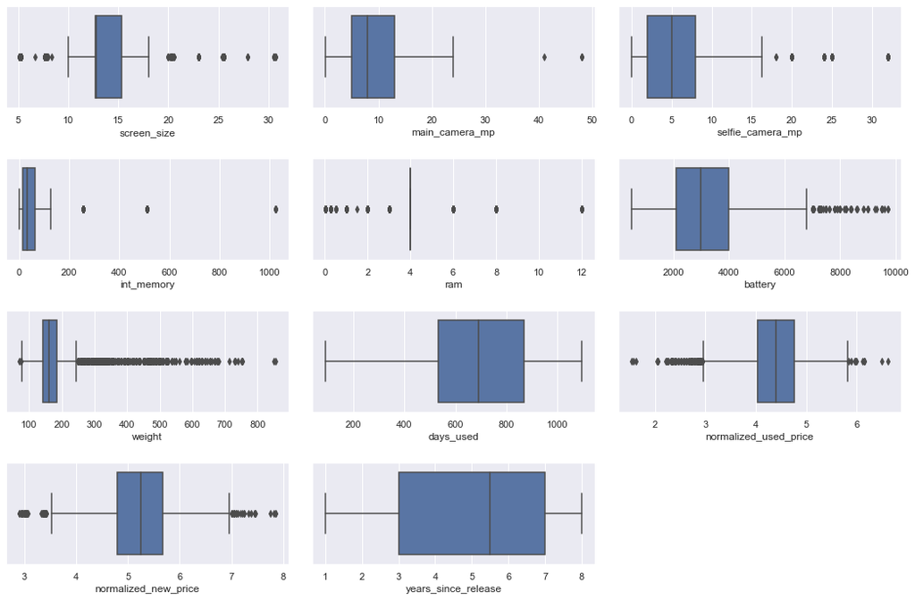

```python
# outlier detection using boxplot
num_cols = df1.select_dtypes(include=np.number).columns.tolist()

plt.figure(figsize=(15, 10))

for i, variable in enumerate(num_cols):
    plt.subplot(4, 3, i+1);
    sns.boxplot(data=df1, x=variable)
    plt.tight_layout(pad=2)

plt.show()
```

Even though outliers are present in the data, I do not believe action is required. The outlier rows represent an accurate data point for valueable numeric variables. Dropping these columns/rows would only hurt model performance.